# Probability and Statistics

# Lab Assignment 1: Naive Bayes Classifier

## Work breakdown

- Viktoria Prokhorova: Data and metrics visualization
- Dmytro Shumskyi: Predict and fit methods
- Mykola Vysotskyi: Predict method, metrics functions, data pre-processing

## Data description

- **4 - spam** This last data set contains SMS messages classified as spam or non-spam (ham in the data set). The task is to determine whether a given message is spam or non-spam.

Each data set consists of two files: *train.csv* and *test.csv*. The first one you will need find the probabilities distributions for each of the features, while the second one is needed for checking how well your classifier works.

## **Outline of the work**

1. **Data pre-processing** (includes removing punctuation marks and stop words, representing each message as a bag-of-words)
2. **Data visualization**
3. **Classifier implementation** (using the training set, calculate all the conditional probabilities in formula (1) and then use those to predict classes for messages in the testing set)
4. **Measurements of effectiveness of your classifier** (accuracy, precision and recall curves, F1 score metric etc)
5. **Conclusions**

## Data pre-processing

```r
# Include all necessary libraries
library(tidytext)
library(readr)
library(dplyr)
```

```r
library(ggplot2)
library(wordcloud)
library(tm)
# Loading stop words
stop_words <- read_file("data/stop_words.txt")
splittedStopWords <- strsplit(stop_words, split='\n')
splittedStopWords <- splittedStopWords[[1]]

# Loading datasets
test <- read_csv("data/test.csv", show_col_types = FALSE)
train <- read_csv("data/train.csv", show_col_types = FALSE)

# Function to calculate words frequencies in given dataframe
freqDataframe <- function(dataframe, column, stop_words = NULL)
{
    dataframe %>%
          unnest_tokens(word, column) %>%
          count(word, sort = TRUE) %>%
        filter(!word %in% stop_words)
}
```

## Data visualization

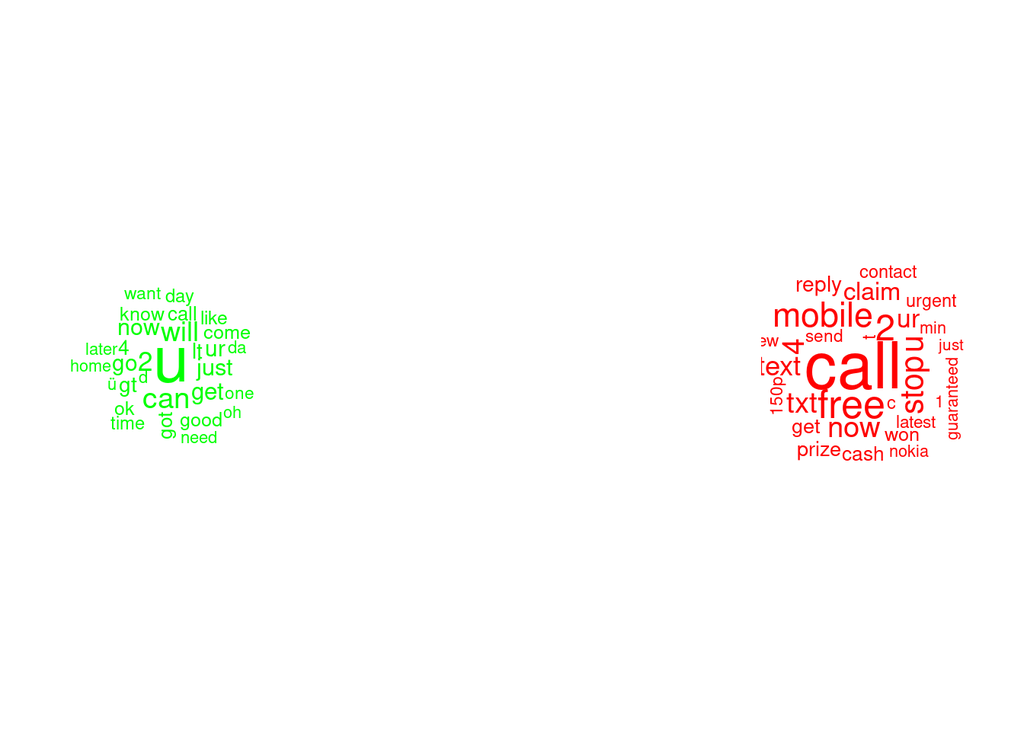

```r
# Words for visualization
hamFreqVis <- freqDataframe(test[test$Category=="ham", ], "Message", splittedStopWords)
spamFreqVis <- freqDataframe(test[test$Category=="spam", ], "Message", splittedStopWords)

par(mfrow = c(1, 3))

wordcloud(words = hamFreqVis$word, freq=hamFreqVis$n, max.words=30, random.order = FALSE,
          colors = 'green')
plot.new()
wordcloud(words = spamFreqVis$word, freq=spamFreqVis$n, max.words=30, random.order=FALSE,
          colors = 'red')
```

## Classifier implementation

```r
# All used metrics implementations
recall <- function(y_true, y_pred) {
    tp <- sum(y_true == y_pred & y_true == TRUE)
    fn <- sum(y_true != y_pred & y_true == TRUE)

    return (tp / (tp + fn))
}

precision <- function(y_true, y_pred) {
    tp <- sum(y_true == y_pred & y_true == TRUE)
    fp <- sum(y_true != y_pred & y_true == FALSE)

    return (tp / (tp + fp))
}

f1Score <- function(y_true, y_pred) {
    recallV <- recall(y_true, y_pred)
    precisionV <- precision(y_true, y_pred)

    return (2 * precisionV * recallV / (precisionV + recallV))
}

accuracy <- function(y_true, y_pred)
{
    return (sum(y_true == y_pred) / length(y_true))
}
```

```r
naiveBayes <- setRefClass("naiveBayes",
    # here it would be wise to have some vars to store intermediate result
    # frequency dict etc. Though pay attention to bag of words!
    fields = list(
        hamFreq = "data.frame",
        spamFreq = "data.frame",

        hamWordsCount = "numeric",
        spamWordsCount = "numeric",

        hamClassProb = "numeric",
        spamClassProb = "numeric"
    ),

    methods = list(
        # prepare your training data as X - bag of words for each of your
        # messages and corresponding label for the message encoded as 0 or 1
        # (binary classification task)
        fit = function(X, y)
        {
            hamFreq <<- freqDataframe(X[X$Category=="ham", ], "Message", splittedStopWords)
            spamFreq <<- freqDataframe(X[X$Category=="spam", ], "Message", splittedStopWords)

            hamWordsCount <<- sum(hamFreq$n)
            spamWordsCount <<- sum(spamFreq$n)

            hamClassProb <<- nrow(X[X$Category=="ham", ]) / nrow(X)
            spamClassProb <<- nrow(X[X$Category=="spam", ]) / nrow(X)
        },

        # return prediction for a single message
        predict = function(message)
        {
            # Check if message is not empty
            if(nchar(message) == 0) {
                  return (NULL)
            }

            # Convert message to bag of words
            wrapperDf <- data.frame(word = message)
            tokens <- unnest_tokens(wrapperDf, word, word) %>% filter(!word %in% splittedStopWords)

            hamProb <- hamClassProb
            spamProb <- spamClassProb

            for (i in 1:nrow(tokens))
            {
                  word <- tokens[i, ]

                    inHamCount <- ifelse(!is.na(any(hamFreq$word == word)) && any(hamFreq$word == word),
                                 hamFreq[hamFreq$word == word, "n"]$n,
                                 0)
                    inSpamCount <- ifelse(!is.na(any(spamFreq$word == word)) && any(spamFreq$word == word),
                                  spamFreq[spamFreq$word == word, "n"]$n,
                                  0)

                    hamProb <- hamProb * (inHamCount + 1) / (hamWordsCount + 2)
                    spamProb <- spamProb * (inSpamCount + 1) / (spamWordsCount + 2)
            }

            return (hamProb > spamProb)
        },

        # score you test set so to get the understanding how well you model
        # works.
        # look at f1 score or precision and recall
        # visualize them
        # try how well your model generalizes to real world data!
        score = function(X_test, y_test)
        {
            y_pred <- lapply(X_test$Message, function(message) { predict(message) })

            scores = c(
                  "accuracy"  = accuracy(y_test, y_pred),
                  "precision" = precision(y_test, y_pred),
                  "recall"    = recall(y_test, y_pred),
                  "f1Score"   = f1Score(y_test, y_pred)
            )

            return (scores)
        }
))

# Create and fit model
model = naiveBayes()
model$fit(train, train$Category)
```

## Measure effectiveness of your classifier

```r
# Example of score results
model$score(test, test$Category == "ham")
```

```
##  accuracy precision    recall   f1Score
## 0.9522654 0.9980450 0.9471243 0.9719181
```

```r
# Get scores for different sizes
trainSizes <- c(0.1, 0.2, 0.3, 0.5, 0.7, 0.8, 0.9, 1.0)

accuracyScores <- c()
precisionScores <- c()
recallScores <- c()
f1Scores <- c()

tmodel = naiveBayes()

for (trainSize in trainSizes)
{
      trainSample <- train[sample(nrow(train), floor(nrow(train) * trainSize)), ]
    tmodel$fit(trainSample, trainSample$Category)
    scores <- tmodel$score(test, test$Category == "ham")

      accuracyScores <- c(accuracyScores, scores["accuracy"])
      precisionScores <- c(precisionScores, scores["precision"])
      recallScores <- c(recallScores, scores["recall"])
      f1Scores <- c(f1Scores, scores["f1Score"])
}
```

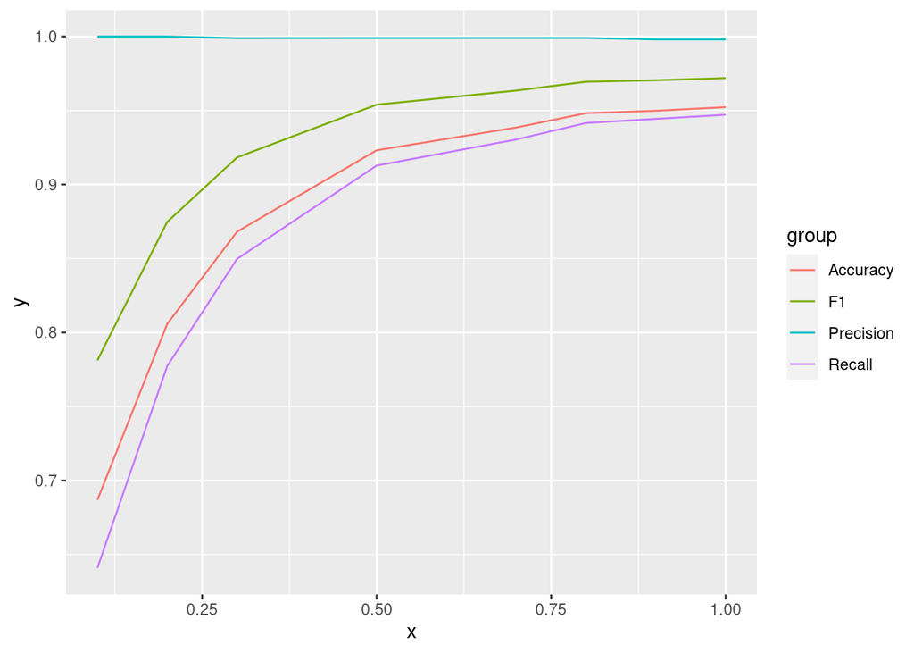

```r
df_reshaped <- data.frame(x = trainSizes,
                       y = c(accuracyScores, precisionScores, recallScores, f1Scores),
                       group = c(rep("Accuracy", length(trainSizes)),
                                 rep("Precision", length(trainSizes)),
                                 rep("Recall", length(trainSizes)),
                                 rep("F1", length(trainSizes))
                                 ))

ggplot(df_reshaped, aes(x, y, col = group)) +  geom_line()
```

#### Failure cases

```r
convert_label <- function(x) { ifelse(x == "ham", TRUE, FALSE) }

y_pred <- lapply(test$Message, function(message) { model$predict(message) })
failureCases <- test[y_pred != convert_label(test$Category), ]

failureCases
```

```
## # A tibble: 59 × 2
##    Category Message
##    <chr>    <chr>
##  1 ham      "Ujhhhhhhh computer shipped out with address to sandiago and parant…
##  2 ham      "Mathews or tait or edwards or anderson"
##  3 ham      "When you get free, call me"
##  4 ham      "Update your face book status frequently :)"
##  5 ham      "CHEERS FOR CALLIN BABE.SOZI CULDNT TALKBUT I WANNATELL U DETAILS L…
##  6 ham      "Erutupalam thandiyachu"
##  7 ham      "Miss call miss call khelate kintu opponenter miss call dhorte lage…
##  8 ham      "Urgh, coach hot, smells of chip fat! Thanks again, especially for …
##  9 ham      "Gettin rdy to ship comp"
## 10 ham      "CHA QUITEAMUZING THAT\u0092SCOOL BABE,PROBPOP IN & CU SATTHEN HUNN…
## # ℹ 49 more rows
```

## Check on real world data

```r
model$predict("") # should return NULL
```

```r
model$predict("Hello, how are you?") # should return TRUE
```

```
## [1] TRUE
```

```r
model$predict("WINNER!! This is the secret code to unlock the money: C3421.") # should return FALSE
```

```
## [1] FALSE
```

## Conclusions

Summarize your work by explaining in a few sentences the points listed below.

- Describe the method implemented in general. Show what are mathematical foundations you are basing your solution on.
- List pros and cons of the method. This should include the limitations of your method, all the assumption you make about the nature of your data etc.
- The method is called **Naive Bayes classifier**. In our case we used is to filter **spam** messages from **non-spam**(ham). Firstly, we calculate frequencies of words to be in spam and ham messages. Forming bag-of-words. After that, for given text message we can calculate its probability to be spam/ham using **Bayes formula**. We assume that all features(words) are **independent**. To find probability of message belong to some class we multiply probability of class by product of probability of each word given the class and divide this by product of probabilities of each word(actually, we can skip this because it is common for each class and is not useful in comparison). Also we used **Laplace Smoothing** to prevent probability of some word being 0.
- **Pros** of this method - easy to implement, computationally light. **Cons** - *naivety* of this method(we assume that all words are independent and do not consider words order), words that often appear in one class can be in other and lead to incorrect classification results.